# Practical Machine Learning Course Project

Aman Karamlou

March 10, 2019

## Summary

One thing that people regularly do is quantify how much of a particular activity they do, but they rarely quantify how well they do it. In this project, the goal is to use data from accelerometers on the belt, forearm, arm, and dumbbell of 6 participants and predict the manner they did exercise (i.e., variable “classe” in the training and testing data sets).

## Loading the Libraries

The followings are the packages used for this exercise.

```r
library(data.table)
library(ggplot2)
library(caret)
library(ISLR)
library(rattle)
library(parallel)
library(doParallel)
```

## Loading and Cleaning the Data

The data has already been partitioned into training and testing data sets and saved in csv formats. The following lines are to load the training and testing data sets.

```r
trainingData <- read.table("pml-training.csv", header = TRUE, sep = ",", na.strings = c("NA", "", "#DIV/0!"))
ValidationData <- read.table("pml-testing.csv", header = TRUE, sep = ",", na.strings = c("NA", "", "#DIV/0!"))
```

The total number of variables (including the outcome “classe”) in the training and the testing set are 160 and 160, respectively. The total number of observations in the training and testing data sets are 19622 and 20, respectively.

The first column of both sets and the last column of the validation set are only the row number of the data which is removed in the following.  
Also, the outcome variable is set aside for now to keep the two sets comparable for cleaning.

```r
classe <- trainingData$classe
trainingData <- subset(trainingData, select = c(-X, -classe))
ValidationData <- subset(ValidationData, select = c(-X, -problem_id))
```

The training set includes several missing observations from different predictors which should be removed from both the training and testing data sets. In the following the variables that are more than 90% missing (“NA”) are excluded. Also, the data might include predictors with little variability. This is handled using “nearZeroVar” command in the following:

```r
missPred <- sapply(trainingData, function(x) (sum(is.na(x))/length(x))>0.9) # missing predictors
trainingData <- trainingData[, !as.vector(missPred)]
ValidationData <- ValidationData[, !as.vector(missPred)]

missPred <- sapply(ValidationData, function(x) (sum(is.na(x))/length(x))>0.9) # missing predictors
ValidationData <- ValidationData[, !as.vector(missPred)]
trainingData <- trainingData[, !as.vector(missPred)]

nzv <- nearZeroVar(trainingData, saveMetrics = TRUE)
trainingData <- trainingData[, !nzv$nzv]
ValidationData <- ValidationData[, !nzv$nzv]
```

Overall, the above operations reduces the total number of predictors to 57. The remaining predictors are:

```r
print(colnames(trainingData[, -ncol(trainingData)]))
```

```
##  [1] "user_name"            "raw_timestamp_part_1" "raw_timestamp_part_2"
##  [4] "cvtd_timestamp"       "num_window"           "roll_belt"
##  [7] "pitch_belt"           "yaw_belt"             "total_accel_belt"
## [10] "gyros_belt_x"         "gyros_belt_y"         "gyros_belt_z"
## [13] "accel_belt_x"         "accel_belt_y"         "accel_belt_z"
## [16] "magnet_belt_x"        "magnet_belt_y"        "magnet_belt_z"
## [19] "roll_arm"             "pitch_arm"            "yaw_arm"
## [22] "total_accel_arm"      "gyros_arm_x"          "gyros_arm_y"
## [25] "gyros_arm_z"          "accel_arm_x"          "accel_arm_y"
## [28] "accel_arm_z"          "magnet_arm_x"         "magnet_arm_y"
## [31] "magnet_arm_z"         "roll_dumbbell"        "pitch_dumbbell"
## [34] "yaw_dumbbell"         "total_accel_dumbbell" "gyros_dumbbell_x"
## [37] "gyros_dumbbell_y"     "gyros_dumbbell_z"     "accel_dumbbell_x"
## [40] "accel_dumbbell_y"     "accel_dumbbell_z"     "magnet_dumbbell_x"
## [43] "magnet_dumbbell_y"    "magnet_dumbbell_z"    "roll_forearm"
## [46] "pitch_forearm"        "yaw_forearm"          "total_accel_forearm"
## [49] "gyros_forearm_x"      "gyros_forearm_y"      "gyros_forearm_z"
## [52] "accel_forearm_x"      "accel_forearm_y"      "accel_forearm_z"
## [55] "magnet_forearm_x"     "magnet_forearm_y"
```

## Model Building and Training

```r
trainingData$classe <- classe
inTrain = createDataPartition(trainingData$classe, p = 3/4, list = FALSE)
training = trainingData[ inTrain,]
testing = trainingData[-inTrain,]
```

Three different approaches are chosen to build the prediction model. These are **Calssification Tree**, **Random Forest**, and **Boosting**. Since the training process is computationally expensive, the recommendations presented [here](https://github.com/lgreski/datasciencectacontent/blob/master/markdown/pml-randomForestPerformance.md) are used to take advantage of all available processors in the computer.

```r
set.seed(123)
cluster <- makeCluster(detectCores() - 1) # convention to leave 1 core for OS
registerDoParallel(cluster)
fitControl <- trainControl(method = "cv", number = 5, allowParallel = TRUE)
modFit_tree <- train(classe~., method = "rpart", data = training, trControl = fitControl)
modFit_rf <- train(classe~., method = "rf", data = training, prox = FALSE, trControl = fitControl)
modFit_boost <- train(classe~., method = "gbm", data = training, verbose = FALSE, trControl = fitControl)
stopCluster(cluster)
registerDoSEQ()
```

### Classification Tree

The following figure shows the decision tree from the performed classification tree method.

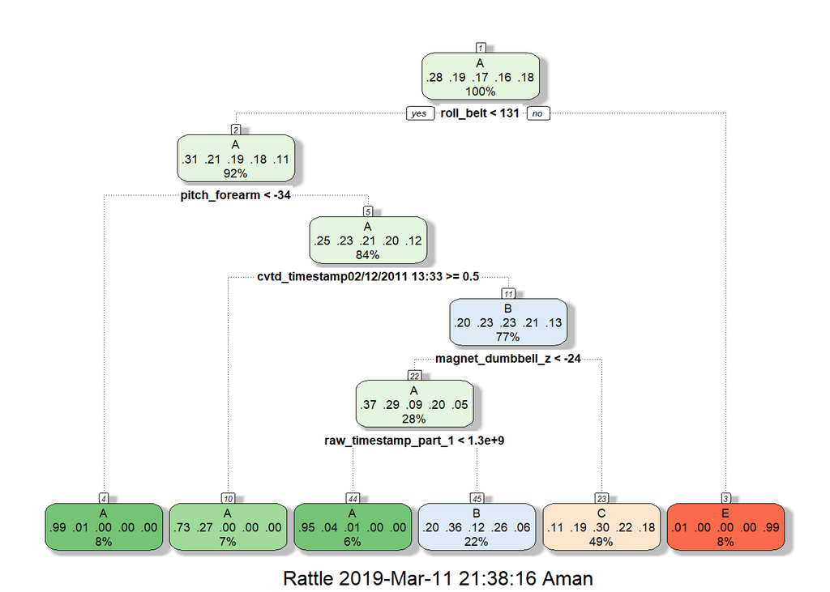

```r
fancyRpartPlot(modFit_tree$finalModel)
```

A summary of the model parameters are presented in the following:

```r
print(modFit_tree)
```

```
## CART
##
## 14718 samples
##    57 predictor
##     5 classes: 'A', 'B', 'C', 'D', 'E'
##
## No pre-processing
## Resampling: Cross-Validated (5 fold)
## Summary of sample sizes: 11776, 11775, 11774, 11774, 11773
## Resampling results across tuning parameters:
##
##   cp          Accuracy   Kappa
##   0.04129878  0.5179382  0.37807375
##   0.04455837  0.4472538  0.25986228
##   0.11487705  0.3162806  0.04864936
##
## Accuracy was used to select the optimal model using the largest value.
## The final value used for the model was cp = 0.04129878.
```

Finally, the model accuracy is presented bellow:

```r
accuracy_tree <- confusionMatrix(testing$classe, predict(modFit_tree, testing))
print(accuracy_tree)
```

```
## Confusion Matrix and Statistics
##
##           Reference
## Prediction   A   B   C   D   E
##          A 930 224 235   0   6
##          B  94 409 446   0   0
##          C   1 146 708   0   0
##          D   0 279 525   0   0
##          E   0  63 445   0 393
##
## Overall Statistics
##
##                Accuracy : 0.4976
##                  95% CI : (0.4835, 0.5116)
##     No Information Rate : 0.481
##     P-Value [Acc > NIR] : 0.01072
##
##                   Kappa : 0.37
##  Mcnemar's Test P-Value : NA
##
## Statistics by Class:
##
##                      Class: A Class: B Class: C Class: D Class: E
## Sensitivity            0.9073   0.3649   0.3001       NA  0.98496
## Specificity            0.8801   0.8573   0.9422   0.8361  0.88724
## Pos Pred Value         0.6667   0.4310   0.8281       NA  0.43618
## Neg Pred Value         0.9729   0.8200   0.5922       NA  0.99850
## Prevalence             0.2090   0.2286   0.4810   0.0000  0.08136
## Detection Rate         0.1896   0.0834   0.1444   0.0000  0.08014
## Detection Prevalence   0.2845   0.1935   0.1743   0.1639  0.18373
## Balanced Accuracy      0.8937   0.6111   0.6212       NA  0.93610
```

### Random Forest

A summary of the model parameters are presented in the following:

```r
print(modFit_rf)
```

```
## Random Forest
##
## 14718 samples
##    57 predictor
##     5 classes: 'A', 'B', 'C', 'D', 'E'
##
## No pre-processing
## Resampling: Cross-Validated (5 fold)
## Summary of sample sizes: 11776, 11774, 11774, 11776, 11772
## Resampling results across tuning parameters:
##
##   mtry  Accuracy   Kappa
##    2    0.9896038  0.9868476
##   40    0.9989805  0.9987105
##   79    0.9984368  0.9980227
##
## Accuracy was used to select the optimal model using the largest value.
## The final value used for the model was mtry = 40.
```

The model accuracy is presented bellow:

```r
accuracy_rf <- confusionMatrix(testing$classe, predict(modFit_rf, testing))
print(accuracy_rf)
```

```
## Confusion Matrix and Statistics
##
##           Reference
## Prediction    A    B    C    D    E
##          A 1395    0    0    0    0
##          B    0  949    0    0    0
##          C    0    0  855    0    0
##          D    0    0    0  804    0
##          E    0    0    0    0  901
##
## Overall Statistics
##
##                Accuracy : 1
##                  95% CI : (0.9992, 1)
##     No Information Rate : 0.2845
##     P-Value [Acc > NIR] : < 2.2e-16
##
##                   Kappa : 1
##  Mcnemar's Test P-Value : NA
##
## Statistics by Class:
##
##                      Class: A Class: B Class: C Class: D Class: E
## Sensitivity            1.0000   1.0000   1.0000   1.0000   1.0000
## Specificity            1.0000   1.0000   1.0000   1.0000   1.0000
## Pos Pred Value         1.0000   1.0000   1.0000   1.0000   1.0000
## Neg Pred Value         1.0000   1.0000   1.0000   1.0000   1.0000
## Prevalence             0.2845   0.1935   0.1743   0.1639   0.1837
## Detection Rate         0.2845   0.1935   0.1743   0.1639   0.1837
## Detection Prevalence   0.2845   0.1935   0.1743   0.1639   0.1837
## Balanced Accuracy      1.0000   1.0000   1.0000   1.0000   1.0000
```

### Boosting

A summary of the model parameters are presented in the following:

```r
print(modFit_boost)
```

```
## Stochastic Gradient Boosting
##
## 14718 samples
##    57 predictor
##     5 classes: 'A', 'B', 'C', 'D', 'E'
##
## No pre-processing
## Resampling: Cross-Validated (5 fold)
## Summary of sample sizes: 11776, 11774, 11774, 11774, 11774
## Resampling results across tuning parameters:
##
##   interaction.depth  n.trees  Accuracy   Kappa
##   1                   50      0.8374101  0.7934505
##   1                  100      0.8962477  0.8686030
##   1                  150      0.9256006  0.9057537
##   2                   50      0.9565162  0.9449454
##   2                  100      0.9867507  0.9832408
##   2                  150      0.9916425  0.9894290
##   3                   50      0.9838290  0.9795437
##   3                  100      0.9934088  0.9916632
##   3                  150      0.9967383  0.9958742
##
## Tuning parameter 'shrinkage' was held constant at a value of 0.1
##
## Tuning parameter 'n.minobsinnode' was held constant at a value of 10
## Accuracy was used to select the optimal model using the largest value.
## The final values used for the model were n.trees = 150,
##  interaction.depth = 3, shrinkage = 0.1 and n.minobsinnode = 10.
```

The model accuracy is presented bellow:

```r
accuracy_boost <- confusionMatrix(testing$classe, predict(modFit_boost, testing))
print(accuracy_boost)
```

```
## Confusion Matrix and Statistics
##
##           Reference
## Prediction    A    B    C    D    E
##          A 1395    0    0    0    0
##          B    0  948    1    0    0
##          C    0    0  851    4    0
##          D    0    0    0  803    1
##          E    0    0    0    0  901
##
## Overall Statistics
##
##                Accuracy : 0.9988
##                  95% CI : (0.9973, 0.9996)
##     No Information Rate : 0.2845
##     P-Value [Acc > NIR] : < 2.2e-16
##
##                   Kappa : 0.9985
##  Mcnemar's Test P-Value : NA
##
## Statistics by Class:
##
##                      Class: A Class: B Class: C Class: D Class: E
## Sensitivity            1.0000   1.0000   0.9988   0.9950   0.9989
## Specificity            1.0000   0.9997   0.9990   0.9998   1.0000
## Pos Pred Value         1.0000   0.9989   0.9953   0.9988   1.0000
## Neg Pred Value         1.0000   1.0000   0.9998   0.9990   0.9998
## Prevalence             0.2845   0.1933   0.1737   0.1646   0.1839
## Detection Rate         0.2845   0.1933   0.1735   0.1637   0.1837
## Detection Prevalence   0.2845   0.1935   0.1743   0.1639   0.1837
## Balanced Accuracy      1.0000   0.9999   0.9989   0.9974   0.9994
```

## Summary and Validation set Prediction

Based on the results presented above, the accuracy of Classification Tree, Random Forest, and Boosting techniques are 0.497553, 1, 0.9987765, respectively. Thus, Random Forest technique shows to be more accurate and is used to predict the validation set as follows:

```r
print(predict(modFit_rf, ValidationData))
```

```
##  [1] B A B A A E D B A A B C B A E E A B B B
## Levels: A B C D E
```